# Linear models II

Etienne Low-Décarie

2017-12-20

# General Linear Models in R: Part 2

## A 2-Way Factorial Analysis of Variance of Limpets

This dataset is taken from the Quinn and Keough book. It is a study looking at density dependent fecundity in limpets in two different seasons. The null hypothesis is that there is no effect of density or season on the production of eggs. Alternatives include there being a density effect that differs between seasons (interaction between density and season) or an additive effect of season and density (no interaction – e.g. slope of density dependence is the same, but means are lower or higher between seasons). > Step 1: Import the limpet data into R and attach the data sheet. Identify the names of the columns in R and do a panel plot of eggs vs. density, split by season

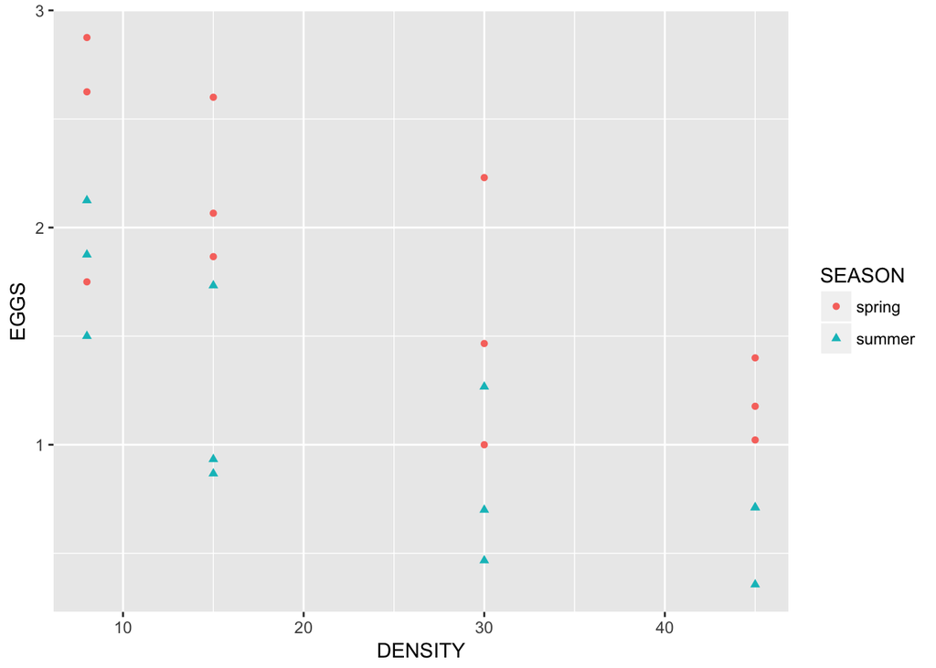

```r
require(ggplot2)
p <- qplot(data=limp,
           x=DENSITY,
           y=EGGS,
           colour=SEASON,
           shape=SEASON)
print(p)
```

Ask yourself now – what kind of analysis are we doing? ANOVA, ANCOVA, Multiple Regression? Which variables are categorical and which are continuous? Can you find out?

```r
str(limp)
```

```
## 'data.frame':    24 obs. of  3 variables:
##  $ DENSITY: int  8 8 8 8 8 8 15 15 15 15 ...
##  $ SEASON : Factor w/ 2 levels "spring","summer": 1 1 1 2 2 2 1 1 1 2 ...
##  $ EGGS   : num  2.88 2.62 1.75 2.12 1.5 ...
```

Based on the graph, what do I expect my 2-way analysis to show – the null hypothesis, the alternative of an interaction, or the alternative of no interaction? To do this analysis, we use the workhorse, lm(), follow this immediately by a check of assumptions, then an examination of the anova table and the coefficients table. lm performs general linear models – these models assume normally distributed errors, but are robust to deviations in sample sizes (unbalanced designs).

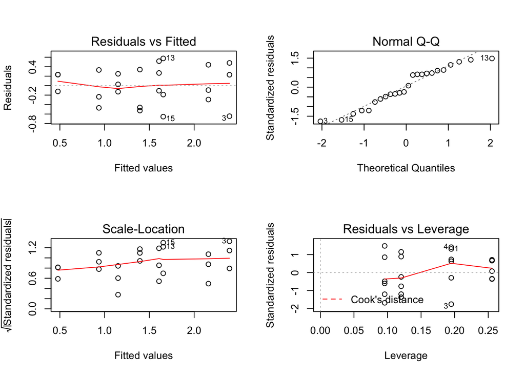

```r
m1<-lm(EGGS~DENSITY*SEASON,
       data=limp)
par(mfrow=c(2,2))
plot(m1)
```

```r
anova(m1)
```

```
## Analysis of Variance Table
##
## Response: EGGS
##                Df Sum Sq Mean Sq F value    Pr(>F)
## DENSITY         1 5.0241  5.0241 30.1971 2.226e-05 ***
## SEASON          1 3.2502  3.2502 19.5350 0.0002637 ***
## DENSITY:SEASON  1 0.0118  0.0118  0.0711 0.7925333
## Residuals      20 3.3275  0.1664
## ---
## Signif. codes:  0 '***' 0.001 '**' 0.01 '*' 0.05 '.' 0.1 ' ' 1
```

```r
summary(m1)
```

```
##
## Call:
## lm(formula = EGGS ~ DENSITY * SEASON, data = limp)
##
## Residuals:
##      Min       1Q   Median       3Q      Max
## -0.65468 -0.25021 -0.03318  0.28335  0.57532
##
## Coefficients:
##                       Estimate Std. Error t value Pr(>|t|)
## (Intercept)           2.664166   0.234118  11.380 3.45e-10 ***
## DENSITY              -0.033650   0.008259  -4.074 0.000591 ***
## SEASONsummer         -0.812282   0.331092  -2.453 0.023450 *
## DENSITY:SEASONsummer  0.003114   0.011680   0.267 0.792533
## ---
## Signif. codes:  0 '***' 0.001 '**' 0.01 '*' 0.05 '.' 0.1 ' ' 1
##
## Residual standard error: 0.4079 on 20 degrees of freedom
## Multiple R-squared:  0.7135, Adjusted R-squared:  0.6705
## F-statistic:  16.6 on 3 and 20 DF,  p-value: 1.186e-05
```

before we go over the details: * why do we assign the model a name `m1`? * What does `DENSITY*SEASON` mean in the model? * What does `par(mfrow=c(2,2))` do? * What should plot(m1) produce?